# Lecture 10: Synthetic control methods and notes on the final

Jack Blundell

PUBLPOL 330D Applied Econometrics for Public Policy, Winter 2020

- My email: jackblundell@stanford.edu
- My (virtual) office hours this week:
- 8.30 - 10.30am Thursday
- 4.30 - 6.30pm Wednesday (Not on Thursday)
- 2.30 - 3.20pm Friday

## 1. Synthetic controls

### 1.1 Setup

In this document I will demonstrate how to apply synthetic control methods in Stata.

You first need to install a package using command `ssc install synth`.

I am going to demonstrate using the `smoking` dataset. This contains state-year cigarette sales per capita, as well as some control variables.

We will use this data to assess California’s anti-smoking legislation introduced in 1989. I first load the data.

```stata
. cd "~/Dropbox/Documents/Teaching/PUBLPOL330D/Lectures/Lecture 10/markdown/"
/Users/jack/Dropbox/Documents/Teaching/PUBLPOL330D/Lectures/Lecture 10/markdown

. use smoking
(Tobacco Sales in 39 US States)
```

We will construct a “synthetic California” from the other states, then compare this synthetic California to actual California.

Before using the `synth` command, we have to tell Stata which variable is our “id” variable and which is our time variable:

```stata
. tsset state year
       panel variable:  state (strongly balanced)
        time variable:  year, 1970 to 2000
                delta:  1 unit
```

The data must be “long”, which your data for the problem set will already be.

### 1.2 Applying synthetic controls

Next I run the synthetic control model:

```stata
. synth cigsale beer(1984(1)1988) lnincome retprice age15to24 cigsale(1988) ///
> cigsale(1980) cigsale(1975), trunit(3) trperiod(1989) figure
──────────────────────────────────────────────────────────────────────────────────────────────────────
Synthetic Control Method for Comparative Case Studies
──────────────────────────────────────────────────────────────────────────────────────────────────────

First Step: Data Setup
──────────────────────────────────────────────────────────────────────────────────────────────────────
control units: for 38 of out 38 units missing obs for predictor lnincome in period 1970 -ignored for a
> veraging
control units: for 38 of out 38 units missing obs for predictor lnincome in period 1971 -ignored for a
> veraging
treated unit: for 1 of out 1 units missing obs for predictor lnincome in period 1970 -ignored for aver
> aging
treated unit: for 1 of out 1 units missing obs for predictor lnincome in period 1971 -ignored for aver
> aging
──────────────────────────────────────────────────────────────────────────────────────────────────────
Data Setup successful
──────────────────────────────────────────────────────────────────────────────────────────────────────
                Treated Unit: California
               Control Units: Alabama, Arkansas, Colorado, Connecticut, Delaware, Georgia, Idaho,
                              Illinois, Indiana, Iowa, Kansas, Kentucky, Louisiana, Maine, Minnesota,
                              Mississippi, Missouri, Montana, Nebraska, Nevada, New Hampshire, New
                              Mexico, North Carolina, North Dakota, Ohio, Oklahoma, Pennsylvania,
                              Rhode Island, South Carolina, South Dakota, Tennessee, Texas, Utah,
                              Vermont, Virginia, West Virginia, Wisconsin, Wyoming
──────────────────────────────────────────────────────────────────────────────────────────────────────
          Dependent Variable: cigsale
  MSPE minimized for periods: 1970 1971 1972 1973 1974 1975 1976 1977 1978 1979 1980 1981 1982 1983
                              1984 1985 1986 1987 1988
Results obtained for periods: 1970 1971 1972 1973 1974 1975 1976 1977 1978 1979 1980 1981 1982 1983
                              1984 1985 1986 1987 1988 1989 1990 1991 1992 1993 1994 1995 1996 1997
                              1998 1999 2000
──────────────────────────────────────────────────────────────────────────────────────────────────────
                  Predictors: beer(1984(1)1988) lnincome retprice age15to24 cigsale(1988)
                              cigsale(1980) cigsale(1975)
──────────────────────────────────────────────────────────────────────────────────────────────────────
Unless period is specified
predictors are averaged over: 1970 1971 1972 1973 1974 1975 1976 1977 1978 1979 1980 1981 1982 1983
                              1984 1985 1986 1987 1988
──────────────────────────────────────────────────────────────────────────────────────────────────────

Second Step: Run Optimization
──────────────────────────────────────────────────────────────────────────────────────────────────────
──────────────────────────────────────────────────────────────────────────────────────────────────────
Optimization done
──────────────────────────────────────────────────────────────────────────────────────────────────────

Third Step: Obtain Results
──────────────────────────────────────────────────────────────────────────────────────────────────────
Loss: Root Mean Squared Prediction Error

─────────────────────
   RMSPE │  1.943233
─────────────────────
──────────────────────────────────────────────────────────────────────────────────────────────────────
Unit Weights:

───────────────┬────────────
         Co_No │ Unit_Weight
───────────────┼────────────
       Alabama │           0
      Arkansas │           0
      Colorado │        .285
   Connecticut │        .101
      Delaware │           0
       Georgia │           0
         Idaho │           0
      Illinois │           0
       Indiana │           0
          Iowa │           0
        Kansas │           0
      Kentucky │           0
     Louisiana │           0
         Maine │           0
     Minnesota │           0
   Mississippi │           0
      Missouri │           0
       Montana │           0
      Nebraska │           0
        Nevada │        .245
 New Hampshire │           0
    New Mexico │           0
North Carolina │           0
  North Dakota │           0
          Ohio │           0
      Oklahoma │           0
  Pennsylvania │           0
  Rhode Island │           0
South Carolina │           0
  South Dakota │           0
     Tennessee │           0
         Texas │           0
          Utah │        .369
       Vermont │           0
      Virginia │           0
 West Virginia │           0
     Wisconsin │           0
       Wyoming │           0
───────────────┴────────────
──────────────────────────────────────────────────────────────────────────────────────────────────────
Predictor Balance:

──────────────────────────────────────────────────────
                               │   Treated  Synthetic
───────────────────────────────+──────────────────────
             beer(1984(1)1988) │     24.28   23.22596
                      lnincome │  10.03176   9.867266
                      retprice │  66.63684   65.40743
                     age15to24 │  .1786624   .1825559
                 cigsale(1988) │      90.1    92.6063
                 cigsale(1980) │     120.2   120.3907
                 cigsale(1975) │     127.1   126.7094
──────────────────────────────────────────────────────
──────────────────────────────────────────────────────────────────────────────────────────────────────

. graph export "fig.png", replace
(file fig.png written in PNG format)
```

The first variable is the outcome variable. The next ones are the predictors, which are sometimes indexed by particular years to tell Stata to average over those years rather than all years. The default for you should be to just average over all years.

The `trunit(3)` tells Stata that the treated state is California (which is coded as `3`). This value should relate to the id variable set in the `tsset` command used earlier.

We also tell Stata when the treatment occurred (`trperiod(1989)`). This should align with the time variable set in `tsset`.

We also tell Stata to generate a figure using the `figure` option, which you should do for the problem set.

We see that the synthetic control is constructed from Colorado, Connecticut, Nevada and Utah. According to the figure generated below, it looks like the policy reduced smoking.

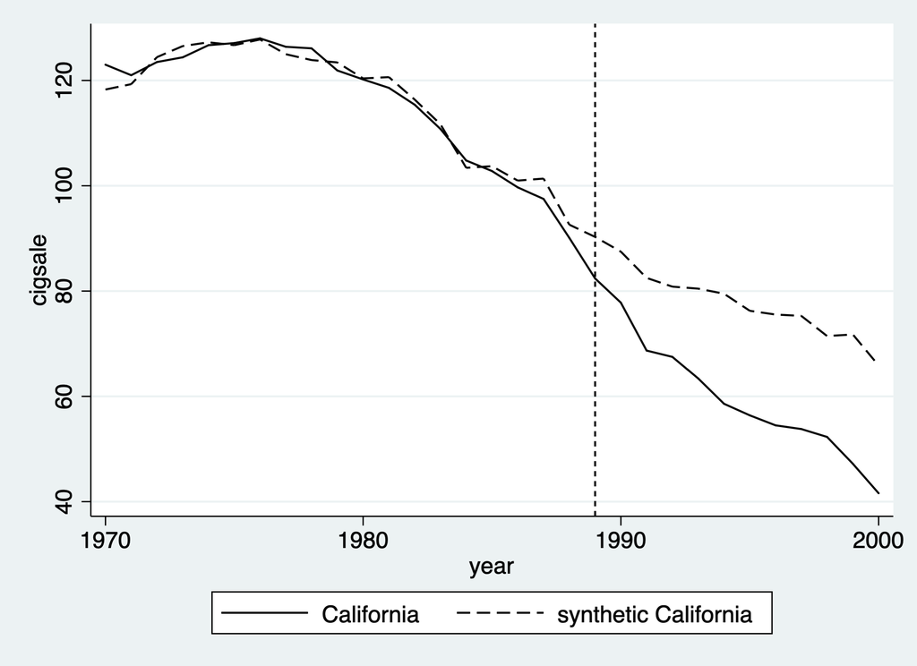

Synthetic control example

One other thing to note is that you can give a `unitnames()` option to Stata which contains the names of the units (countries usually), which helps with the labelling.

### 1.3 Inference and credibility

Inference is more difficult in synthetic control than in previous cases, since there is only one treated unit. Instead, we use “placebo tests”. To quote AJPS2015: “This alternative model of inference is based on the premise that our confidence that a particular synthetic control estimate reflects the impact of the intervention under scrutiny would be severely undermined if we obtained estimated effects of similar or even greater magnitudes in cases where the intervention did not take place.”

The basic idea with these tests is that we pretend that the treatment struck a different unit or the same unit at a different time. We then compare the results of these placebo treatments to our actual treatment.

In the problem set please discuss this, but I will not expect you to implement it in the Stata code. If you would like to implement, I would also suggest looking at the `synth_runner` package, but this is not neccessary for the purpose of the assignment.

When discussing synthetic control methods, you want to consider the following: + How well does the synthetic version of the treated unit match the actual treated unit in the pre-period? + How plausible are the chosen units which are used to construct the counterfactual? For example, in a cross country study where we investigate the impact of Coronavirus on the Italian economy, would it make sense if New Zealand (very far away) were used to generate the synthetic control? + Could it be that the treatment actually affected some of the control areas? These types of spillover effects would lead to a biased estimate. (See the discussion in AJPS2015 page 10)

## 2. Final project

For the final project, we would like to see you demonstrate that you have taken away some of the key topics discussed in the course and are able to apply them to a current policy question.

A “pre-analysis” plan is your plan for a research project. You might like to imagine that you are writing this for a funding body who you would like to convince to fund the project. Imagine that the body is made up of experts in applied econometrics, so you will be fine to use technical language and should be thorough / precise.

As with the assignments, there is no one correct answer to the question. There are lots of ways of answering this which are equally valid. My reccomendation would be to start very simple and move from there.

The report needs to show that you have thought clearly about the research question are able to link it to class material. It should involve the following:

- What type of data would you need? What will be the unit of observation? Will there be a time element or will it just be cross-sectional analysis? What would be the important control variables you want to have?
- What type of methods wouldn’t work? Why not? This is your opportunity to bring in a broader set of methods that we have covered and discuss why these can’t be used here.
- Propose one or more methods which could work and discuss how these methods would be applied.
- Discuss the problems with your methods. Are there any issues with credibility? (There always are)
- How would you demonstrate robustness?

We do not expect you to be an expert on Brexit and we will not mind if some of the institutional details are perfect. Rather, we expect you to be able to link the event to the methods covered in the course.